# Supervised ML in R with Tidymodels

Raimundo Sanchez, PhD

# 1. Introduction to Machine Learning

Machine learning is a dynamic field that empowers us to model intricate patterns within data, enabling predictions and decisions without explicit declaring the relationship between variables. Its applications span a wide range of domains, from healthcare to finance and even self-driving cars.

Machine learning models primarily seek to uncover meaningful patterns within a set of input features or characteristics $\vec{x}$, aiming to predict or understand an output variable $y$. This connection is established through the application of a mathematical function, encapsulating the intricate relationships inherent in the data:

$$y = f(\overrightarrow{x})$$

In most cases, machine learning models operate most effectively when the input data is in numeric format. Consequently, non-numeric data often requires encoding or transformation to facilitate processing by machine learning algorithms. This transformation is a critical preprocessing step, ensuring seamless operation and the extraction of valuable insights from the data.

## 1.1 The “Black-Box” Perspective

Machine learning models employ various strategies to establish relationships between the variables under study. Some of these strategies are highly intricate and can be challenging for humans to comprehend, often resulting in what is commonly referred to as a “black-box” approach to unraveling complex relationships within the data. These “black-box” models are remarkably flexible and adept at capturing intricate, non-linear relationships in the data. While excelling in predictive power, they may lack transparency, making it challenging to comprehend and explain the inner workings of the model.

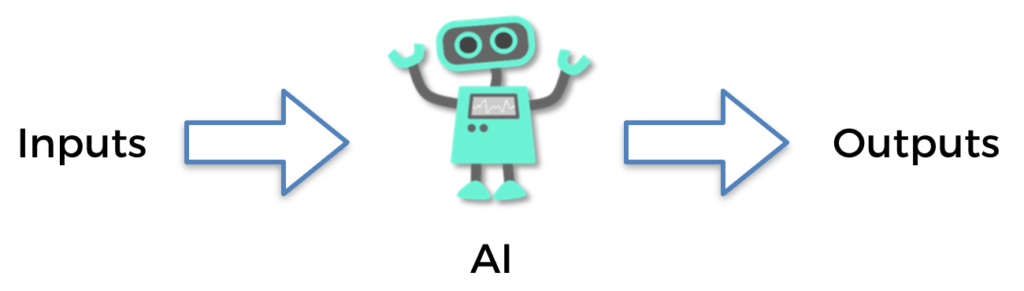

It’s important to understand that the patterns these models identify are established numerically, and their presence doesn’t necessarily imply causation. Instead, they reveal associations and correlations within the data. Therefore, it’s essential to exercise caution when attributing causation solely based on these observed patterns.

This trade-off between predictive performance and interpretability is a common consideration when choosing a machine learning algorithm for a specific problem. Depending on the application, one might opt for more interpretable models or employ techniques to gain insights into complex relationships, even within the “black-box” models.

## 1.2 Model Complexity and Overfitting

Machine learning models often come equipped with numerous parameters, offering the flexibility to capture intricate data relationships. However, this can lead to a common challenge in machine learning known as overfitting. Overfitting occurs when a model becomes excessively tailored to the training data, capturing noise and “memorizing” fluctuations rather than capturing genuine underlying patterns. Consequently, when exposed to new data, the model’s performance may deteriorate.

Conversely, overly simplistic models may underfit the training data, failing to capture critical patterns. Striking the right balance between model complexity and generalization is a fundamental aspect of machine learning model selection and training.

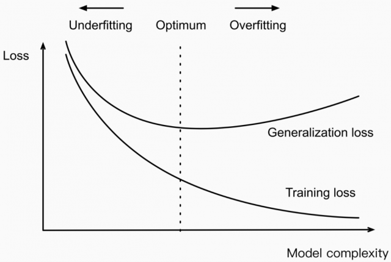

## 1.3 Preventing Overfitting Through Data Sampling

Sampling techniques, including data splitting and cross-validation, are essential for avoiding overfitting in machine learning. Data splitting creates separate training and testing sets, allowing us to assess a model’s generalization to new data. Cross-validation takes it a step further by repeatedly splitting the data into subsets, providing a more comprehensive evaluation. These techniques help fine-tune models, select the best ones, and ensure robust and reliable machine learning systems

[figure not shown]

# 2. Types of Machine Learning

Machine learning algorithms are systematically grouped based on the specific relationship they seek to model between input and output data. These algorithms are predominantly categorized into two fundamental types: supervised and unsupervised learning.

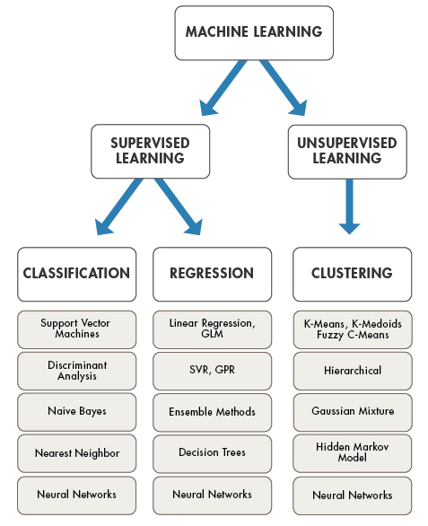

## 2.1 Supervised Learning

In supervised learning, the algorithm learns from a labeled dataset, pairing input data $\vec{x}$ with corresponding output data $y$. This implies that we know the values of $y$, so during the learning phase, the model adjusts its parameters in order to reduce the prediction error of $\hat{y}$. The primary tasks in supervised learning include:

- **Classification**: Models classify input data into predefined categories or classes.
- **Regression**: Models predict continuous numeric values.

## 2.2 Unsupervised Learning

Unsupervised learning algorithms operate with unlabeled data, which means that we don’t have any $y$ values available. Therefore, their primary aim is to uncover patterns, structures, or relationships within the input data. A key task in unsupervised learning is **Clustering**, where similar data points are grouped together based on shared characteristics.

# 3. The Tidymodels and nycflights13 packages

The practical examples in this workshop will be based on two R packages: tidymodels and nycflights13.

### 3.1 Tidymodels: A powerful wrapper for ML packages in R

The **Tidymodels** package is a powerful and user-friendly framework for performing supervised machine learning tasks in the R programming language. It is designed to provide a consistent and tidy approach to building, tuning, and evaluating machine learning models. Tidymodels embraces the principles of the Tidyverse, making it a seamless extension of the R ecosystem for data science and analysis.

With Tidymodels, you can create, train, and evaluate machine learning models while adhering to the principles of reproducibility, consistency, and clarity. It offers a structured and organized workflow, making it easier for data scientists and analysts to understand and communicate their modeling process. Tidymodels is particularly useful for tasks such as classification, regression, and feature engineering.

```r
# install.packages("tidymodels")

library(tidymodels)
```

### 3.2 NYC Flight Data for Supervised Machine Learning

Before moving into the tidymodels components, let’s introduce the dataset we’ll be using in this workshop.

```r
# install.packages("nycflights13")

library(nycflights13)

summary(flights)
```

```
##       year          month             day           dep_time    sched_dep_time
##  Min.   :2013   Min.   : 1.000   Min.   : 1.00   Min.   :   1   Min.   : 106
##  1st Qu.:2013   1st Qu.: 4.000   1st Qu.: 8.00   1st Qu.: 907   1st Qu.: 906
##  Median :2013   Median : 7.000   Median :16.00   Median :1401   Median :1359
##  Mean   :2013   Mean   : 6.549   Mean   :15.71   Mean   :1349   Mean   :1344
##  3rd Qu.:2013   3rd Qu.:10.000   3rd Qu.:23.00   3rd Qu.:1744   3rd Qu.:1729
##  Max.   :2013   Max.   :12.000   Max.   :31.00   Max.   :2400   Max.   :2359
##                                                  NA's   :8255
##    dep_delay          arr_time    sched_arr_time   arr_delay
##  Min.   : -43.00   Min.   :   1   Min.   :   1   Min.   : -86.000
##  1st Qu.:  -5.00   1st Qu.:1104   1st Qu.:1124   1st Qu.: -17.000
##  Median :  -2.00   Median :1535   Median :1556   Median :  -5.000
##  Mean   :  12.64   Mean   :1502   Mean   :1536   Mean   :   6.895
##  3rd Qu.:  11.00   3rd Qu.:1940   3rd Qu.:1945   3rd Qu.:  14.000
##  Max.   :1301.00   Max.   :2400   Max.   :2359   Max.   :1272.000
##  NA's   :8255      NA's   :8713                  NA's   :9430
##    carrier              flight       tailnum             origin
##  Length:336776      Min.   :   1   Length:336776      Length:336776
##  Class :character   1st Qu.: 553   Class :character   Class :character
##  Mode  :character   Median :1496   Mode  :character   Mode  :character
##                     Mean   :1972
##                     3rd Qu.:3465
##                     Max.   :8500
##
##      dest              air_time        distance         hour
##  Length:336776      Min.   : 20.0   Min.   :  17   Min.   : 1.00
##  Class :character   1st Qu.: 82.0   1st Qu.: 502   1st Qu.: 9.00
##  Mode  :character   Median :129.0   Median : 872   Median :13.00
##                     Mean   :150.7   Mean   :1040   Mean   :13.18
##                     3rd Qu.:192.0   3rd Qu.:1389   3rd Qu.:17.00
##                     Max.   :695.0   Max.   :4983   Max.   :23.00
##                     NA's   :9430
##      minute        time_hour
##  Min.   : 0.00   Min.   :2013-01-01 05:00:00.00
##  1st Qu.: 8.00   1st Qu.:2013-04-04 13:00:00.00
##  Median :29.00   Median :2013-07-03 10:00:00.00
##  Mean   :26.23   Mean   :2013-07-03 05:22:54.64
##  3rd Qu.:44.00   3rd Qu.:2013-10-01 07:00:00.00
##  Max.   :59.00   Max.   :2013-12-31 23:00:00.00
##
```

In this workshop, our primary task will involve predicting whether an aircraft will experience a delay of more than 15 minutes upon arrival. This prediction will be based on a comprehensive set of attributes, including Departure time, Flight number, Origin airport, Destination airport, Flight air time, Distance of the flight, Airline carrier, Flight date and Time of the flight

```r
# install.packages("tidyverse")

library(tidyverse)

#data preparation
flight_data <-
  flights %>%
  mutate(
    # Convert the arrival delay to a dichotomous values
    arr_delay = ifelse(arr_delay >= 15, "late", "on_time"),
    # We will use the date (not date-time) in the recipe below
    date = lubridate::as_date(time_hour)
  ) %>%
  # Only retain the specific columns we will use
  select(dep_time, flight, origin, dest, air_time, distance,
         carrier, date, arr_delay, time_hour) %>%
  # Exclude missing data
  na.omit() %>%
  # For creating models, it is better to have qualitative columns
  # encoded as factors (instead of character strings)
  mutate_if(is.character, as.factor)  %>%
  # Keep a sample of 10000 for reducing processing time
  sample_n(10000)

# we can check that 24% of the dataset was late
flight_data %>%
  count(arr_delay) %>%
  mutate(prop = n/sum(n))
```

```
## # A tibble: 2 × 3
##   arr_delay     n  prop
##   <fct>     <int> <dbl>
## 1 late       2399 0.240
## 2 on_time    7601 0.760
```

# 4. Key Components of the Tidymodels Package

Tidymodels comprises several essential components that work together to streamline the model building and evaluation process.

## 4.1 Model Specifications

Tidymodels offers a diverse selection of machine learning algorithms, allowing you to specify them using a consistent syntax. Many of these algorithms require parameter definitions, including the choice of the modeling mode (which can be either regression or classification) and the selection of an engine. Tidymodels serves as a convenient wrapper for various machine learning libraries in R, simplifying the process of choosing and implementing the right algorithm for your specific task.

These are just brief introductions to some model. Each one has its unique characteristics, advantages, and use cases in machine learning.

### 4.1.1 Decision Trees

Decision Trees segment data by input features, guiding decisions through a tree-like structure. Their pros include interpretability, and ease of handling non-linear data. However, decision trees may exhibit bias towards the majority class in imbalanced datasets.

```r
tree_model <-
  decision_tree(tree_depth = 10, min_n = 5) %>%
  set_mode("classification") %>%
  set_engine("rpart")
```

### 4.1.2 Logistic Regression

Logistic Regression models the probability of an instance belonging to a specific class with a linear model, making it one of the first and most widely used binary classification algorithm. It has a high interpretability, computational efficiency, and resistance to overfitting, particularly when dealing with smaller feature sets. However, Logistic Regression assumes linearity, which may limit its performance on complex, non-linear data.

```r
logistic_model <-
  logistic_reg() %>%
  set_mode("classification") %>%
  set_engine("glm")
```

### 4.1.3 Naive Bayes

Naive Bayes models applyies Bayes’ theorem to calculate the probability of a class given a set of feature values, assuming that features are conditionally independent. It has fast training and prediction times, especially on high-dimensional data, and it can perform well with small datasets. However the “naive” assumption of feature independence, which may not hold in all cases and can limit its performance.

```r
bayes_model <-
  naive_Bayes() %>%
  set_mode("classification") %>%
  set_engine("klaR")
```

### 4.1.4 Multi-layer Perceptron

Multilayer Perceptron (MLP) is a neural network model consisting of multiple layers of interconnected functions with adjustable parameters. This architecture excels at modeling intricate, non-linear relationships in data, making it versatile for various machine learning tasks. However, MLPs can be susceptible to overfitting, especially with limited data, and their complex structure may reduce model interpretability.

```r
mlp_model <-
  mlp(hidden_units = 10) %>%
  set_mode("classification") %>%
  set_engine("nnet")
```

### 4.1.5 Random Forest

Random Forest is an ensemble machine learning model that combines multiple decision trees. It aggregates their individual predictions to make more accurate and robust classifications. Pros of Random Forest include high accuracy, resistance to overfitting, and the ability to handle large datasets with numerous features. However, they may be less interpretable due to the ensemble structure and can be computationally expensive.

```r
randforest_model <-
  rand_forest(trees = 15) %>%
  set_mode("classification") %>%
  set_engine("ranger")
```

### 4.1.6 K-nearest Neighbors

K-nearest Neighbors (K-NN) determines the class of a data point by considering the classes of its k-nearest neighbors in the feature space. Pros of k-NN include ease of implementation, its capacity to adapt to the data to capture complex relationships. However, k-NN is also computationally intensive and do not scale well with high-dimensional data.

```r
knn_model <-
  nearest_neighbor(neighbors  = 5) %>%
  set_mode("classification") %>%
  set_engine("kknn")
```

### 4.1.7 Support Vector Machines

Support Vector Machines (SVMs) identifies a decision boundary, known as a hyperplane, to separate data into different classes. They are very effective in handling high-dimensional data and is robust against overfitting. However, SVMs can be computationally demanding, particularly on large datasets.

```r
svm_model <-
  svm_poly(degree = 3) %>%
  set_mode("classification") %>%
  set_engine("kernlab")
```

## 4.2 Data Sampling

Tidymodels provides a diverse set of techniques for data sampling. Two primary methods in this toolkit are data splitting and cross-validation. These techniques are instrumental in evaluating how well your models generalize to new, unseen data and assist in mitigating common issues such as overfitting.

Resampling methods in Tidymodels play a critical role in refining the robustness and reliability of your models, ensuring that they can make accurate predictions in real-world scenarios.

```r
# we generate one single split of our data, 75% training set and 25% test set
data_split <- initial_split(flight_data, prop = 3/4)

# Create data frames for the two sets:
train_data <- training(data_split)
test_data  <- testing(data_split)

# we can also generate several splits, also known as v-fold cross validation
cv <- vfold_cv(train_data, v = 5)
```

## 4.3 Recipes

Recipes in Tidymodels serve as a powerful tool for explicitly defining the relationship between dependent $y$ and independent variables $\overrightarrow{x}$ in your machine learning workflow. They play a pivotal role in data preprocessing and feature engineering, allowing you to set the exact steps necessary to prepare your data for modeling.

With recipes, you can clearly specify the transformation and manipulation of features, ensuring that the data aligns with the requirements of your machine learning model (e.g. all variables must be numeric). This includes tasks such as encoding categorical variables, scaling numeric features, and handling missing data.

Recipes provide a structured, reproducible way to prepare your data, enhancing the transparency and control over the preprocessing pipeline. By explicitly defining the steps involved, you can more effectively ensure that your data is appropriately structured and ready for modeling. This contributes to the overall success of your machine learning endeavors and helps you uncover meaningful insights from your data.

```r
# simple recipe
flights_rec_simple <-
  # we model delays as a function of numeric variables available in train_data
  recipe(arr_delay ~ dep_time + distance + time_hour, data = train_data)

# complex recipe including preprocessing steps
flights_rec <-
  # we model delays as a function of all variables
  recipe(arr_delay ~ ., data = train_data) %>%
  # inform the model that some variables are used as ID and should be ignored in recipe
  update_role(flight, time_hour, new_role = "ID") %>%
  # generate features dow and month from date column
  step_date(date, features = c("dow", "month")) %>%
  # generate holiday feature based on US holidays
  step_holiday(date,
               holidays = timeDate::listHolidays("US"),
               keep_original_cols = FALSE) %>%
  # econde all categorical variables as dummys
  step_dummy(all_nominal_predictors()) %>%
  # remove predictors with zero variance
  step_zv(all_predictors())
```

## 4.4 Workflows

Workflows in Tidymodels bring together the recipe and the model specification into a single coherent structure, streamlining the modeling process.

```r
# create a workflow for our problem
wf_nycflights <-
  workflow() %>%
  # add a recipe
  add_recipe(flights_rec) %>%
  # add a model
  add_model(tree_model)


# fit our workflow with initial data split
flights_fit <-
  wf_nycflights %>%
  fit(data = train_data)

# run our workflow with cross validation splits
flights_cv <-
  wf_nycflights  %>%
  fit_resamples(cv)
```

## 4.5 Metrics

You can easily calculate and compare model performance metrics to evaluate the quality of your models.

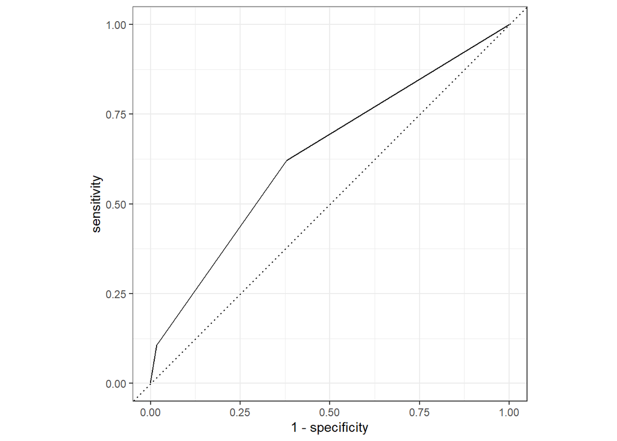

```r
# we will compute the ROC curve of a model and its respective AUC

# start with the fitted workflow
 flights_fit %>%
  # enrich test data with model predictions
  augment(test_data) %>%
  # compute the ROC curve between real delay and predictions
  roc_curve(truth = arr_delay, .pred_late) %>%
  # generate plot
  autoplot()
```

```r
 flights_fit %>%
  augment(test_data) %>%
  # compute the AUC
  roc_auc(truth = arr_delay, .pred_late)
```

```
## # A tibble: 1 × 3
##   .metric .estimator .estimate
##   <chr>   <chr>          <dbl>
## 1 roc_auc binary         0.636
```

```r
# we can also collect metrics for all the v-fold cross validation
 flights_cv %>%
   collect_metrics()
```

```
## # A tibble: 2 × 6
##   .metric  .estimator  mean     n std_err .config
##   <chr>    <chr>      <dbl> <int>   <dbl> <chr>
## 1 accuracy binary     0.773     5 0.00384 Preprocessor1_Model1
## 2 roc_auc  binary     0.650     5 0.00782 Preprocessor1_Model1
```

## 4.6 Hyperparameter Tuning

Finally, Tidymodels provides support for hyperparameter tuning, enabling you to optimize your model’s performance. By systematically exploring different combinations of hyperparameters, you can pinpoint the settings that deliver the best results for your unique problem. Tidymodels simplifies the hyperparameter tuning process, making it more accessible and efficient for model optimization.

```r
# start by defining the model and the hyper parameters we want to tune

tune_spec <-
  # will use decision tree
  decision_tree(
    # the tune() acts as a placeholder that will allow us to tune later in the process
    cost_complexity = tune(),
    tree_depth = tune()
  ) %>%
  set_engine("rpart") %>%
  set_mode("classification")

# generate all the possible values we will test for each hyper parameter
tree_grid <- grid_regular(cost_complexity(),
                          tree_depth(),
                          levels = 5)

# create a workflow for parameter tuning
tree_wf <-
  workflow() %>%
  add_model(tune_spec) %>% # we included the model to be tuned into this workflow
  add_recipe(flights_rec)

# carry out the tuning. This approach is a brute force method and can be computationally intensive.
tree_res <-
  tree_wf %>%
  tune_grid(
    resamples = cv,
    grid = tree_grid
    )

# collect metrics for all the values considered
tree_res %>%
  collect_metrics()
```

```
## # A tibble: 50 × 8
##    cost_complexity tree_depth .metric  .estimator  mean     n std_err .config
##              <dbl>      <int> <chr>    <chr>      <dbl> <int>   <dbl> <chr>
##  1    0.0000000001          1 accuracy binary     0.761     5 0.00420 Preproces…
##  2    0.0000000001          1 roc_auc  binary     0.5       5 0       Preproces…
##  3    0.0000000178          1 accuracy binary     0.761     5 0.00420 Preproces…
##  4    0.0000000178          1 roc_auc  binary     0.5       5 0       Preproces…
##  5    0.00000316            1 accuracy binary     0.761     5 0.00420 Preproces…
##  6    0.00000316            1 roc_auc  binary     0.5       5 0       Preproces…
##  7    0.000562              1 accuracy binary     0.761     5 0.00420 Preproces…
##  8    0.000562              1 roc_auc  binary     0.5       5 0       Preproces…
##  9    0.1                   1 accuracy binary     0.761     5 0.00420 Preproces…
## 10    0.1                   1 roc_auc  binary     0.5       5 0       Preproces…
## # ℹ 40 more rows
```

```r
# select the best performing model according to accuracy
best_tree <- tree_res %>%
  select_best("accuracy")

# create a final definitive workflow with the best model
final_wf <-
  tree_wf %>%
  finalize_workflow(best_tree)

# train the final workflow with the all training data
final_fit <-
  final_wf %>%
  fit(data = train_data)
```